# Predictive modeling for qualitative activity recognition

Enrique Bertrand

24th May 2016

# 1 Executive summary

Through a set of body and device sensors and the appropriate predictive classification model is possible to quantify how well or bad a physical activity is performed. The main purpose of this study is to develop a sufficiently precise model for predicting the quality category (between five different) that corresponds to a concrete observation.

Tree classification models -Classification and Regression Trees (CART), Random Forest (RF), and Generalized Boosted Models (GBM)-, are trained from an experimental dataset that has been collected in the context of a weight lifting exercise supervised by professional coaches. Then their results are compared in terms of accuracy. This analysis is carried out with the help of the `caret` package and its cross-validation capabilities.

The results show that GBM and RF models are much more precise classifiers than CART, although the computational cost (especially with GBM) is significantly higher. Both methods GBM and RF have a similar accuracy (> 0.99; GBM slightly better) and they predict the same results when they are confronted with the 20 cases testing dataset (probability of correct results $\approx$ 0.9). After calculating the corresponding p-values, we fail in rejecting the null hypothesis that RF accuracy is equal to GBM accuracy. Accordingly, we choose the RF model due to its lower computational demands.

# 2 Experimental datasets: Loading, exploratory analysis and cleaning

Preliminary warning: all the R code is included in the Appendices: I - R Code, at the end of this report, and referenced in the corresponding section. The Appendices: II - Model’s details cover detailed info about the training process and results of built models.

## 2.1 Loading files and generating datasets

Two files (csv format) with training and testing data that collect the experimental results have been provided by the group [Groupware@LES](http://groupware.les.inf.puc-rio.br/har) and they are available in a cloud site. If the files are not yet locally available they are downloaded from the source.

Once downloaded, the csv files are converted to two raw datasets: `wle.raw` and `wle.testing.raw` (from “weight lifting exercise”). A preliminary inspection of the csv files shows that there are numerous incomplete observations, with NA type cells that contain different “empty” values: blanks, “#DIV/0!” strings, and “NA” strings. Moreover, the first column simply refers to the row number. The R code generates the raw datasets taking these aspects into account:

Go to appendix Loading files and generating raw datasets to see the R code used for this phase.

## 2.2 Exploratory analysis

```
   A    B    C    D    E
5580 3797 3422 3216 3607
```

The value as predictors of the other 158 variables is relative due to the fact that the content of most of them is mainly NAs:

```
 Number of variables with > 90% of NA values: 100
```

Go to the appendix Exploratory analysis to see the R code used for this phase.

## 2.3 Cleaning the datasets

First, we must proceed to clean the `training` dataset solving three issues related with columns that highly impact in the quality of the predicting models:

1. Near zero variation columns.
2. Mostly NAs columns (NAs > 90%)
3. Highly correlated columns (correlation > 95%)

All the columns detected with any of these problems must be ignored. Moreover, the six first columns contain auxiliary information for the observations with no relevance for predictions.

The last step is to convert the outcome `classe` to a categorical variable and to select the same columns in the `testing` dataset that in the `training` one to make the predictions.

The final result are a `wle` and a `wle.testing` clean datasets with only 48 predictors.

Go to the appendix Cleaning the datasets to see the R code used for this phase.

# 3 Predictive modeling of the weight lifting activity

The main purpose of this study is to develop a sufficiently precise model for predicting the activity class that corresponds to every experimental observation in the weight lifting dataset. We are facing a classification problem where the categorical outcome, the variable `classe`, has multiple values.

For this kind of problems, we can apply several classification models, all of them quite different in terms of computational cost, interpretability, potential accuracy, etc. In practice, we will evaluate the following three models:

1. Classification and Regression Trees (CART)
2. Random Forest (RF)
3. Generalized Boosted Model (GBM)

The metric used for comparing the models will be the accuracy (total true predictions / total predictions).

We will handle our analysis with the help of the `caret` package for three reasons:

- It offers a common interface to the basic modeling operations for any of these models.
- It directly supports a cross-validation approach for finding the parameter values that lead to the minimum error in the final model.
- It includes functions to compare accuracy of different models in terms of confidence intervals and p-values through t-test.

## 3.1 Preliminary steps: cross validation configuration and dataset splitting

The `caret` package can use a cross validation approach (a resampling method) to select the values of the model parameters that lead to the minimum error in the train phase. In our case, we will fix the number of k-folds to 5.

The price to pay, the computational cost of considering resampling, can be mitigated in some way using the parallel computing capabilities offered in R by the `parallel` package for Windows/Intel platforms.

Even with a cross validation approach is worthy to split the training dataset in two subsets, `training` (60%) and `validating` (40%), as we want to compare the accuracy of different models over the `validating` subset. Moreover, reducing the size of the `training` subset makes more feasible some heavy computations with the RF and GBM models in a limited resources scenario (personal laptop).

From now and in order to guarantee the reproducibility, a seed is fixed before any function that implies sampling or resampling.

Go to the appendix Preliminary steps: cross validation configuration and dataset splitting to see the R code used for this phase.

## 3.2 Classification and Regression trees (CART)

Our CART model will be based on the `rpart` package. In this case, the unique parameter that can be optimized in `caret` through cross-validation is the complexity (`cp`). We will provide a grid of `cp` values to the `train()` function.

The most challenging task with CART models is to find a balance between interpretability and complexity of the final tree. Through the parameter `minbucket`, which determines the minimum number of observation in terminal nodes, we can reduce the number of leafs (pruning the tree). Taking into account that we have around 2,000 thousand observations for every class in the training dataset, we choose a conservative value of 200.

Cross validation shows how the accuracy depends on the complexity parameter (`cp`):

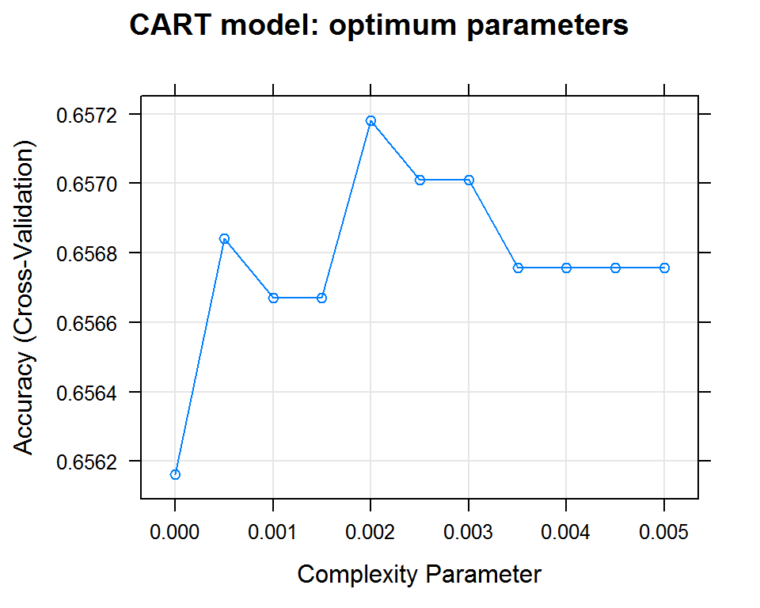

Now we apply the final model, which has been calculated with cp = 0.002, to the `validating` subset in order to determine a realistic accuracy. We can also estimate the probability of predicting the 20 test cases correctly.

```
Confusion Matrix and Statistics

          Reference
Prediction    A    B    C    D    E
         A 1889  173   22   41  115
         B  108  901  125  115  148
         C   54  144  964  100  167
         D  134  145  164  967  211
         E   47  155   93   63  801

Overall Statistics

               Accuracy : 0.7038
                 95% CI : (0.6936, 0.7139)
    No Information Rate : 0.2845
    P-Value [Acc > NIR] : < 2.2e-16

                  Kappa : 0.6258
 Mcnemar's Test P-Value : < 2.2e-16

Statistics by Class:

                     Class: A Class: B Class: C Class: D Class: E
Sensitivity            0.8463   0.5935   0.7047   0.7519   0.5555
Specificity            0.9375   0.9216   0.9282   0.9003   0.9441
Pos Pred Value         0.8433   0.6450   0.6746   0.5965   0.6911
Neg Pred Value         0.9388   0.9043   0.9370   0.9488   0.9041
Prevalence             0.2845   0.1935   0.1744   0.1639   0.1838
Detection Rate         0.2408   0.1148   0.1229   0.1232   0.1021
Detection Prevalence   0.2855   0.1781   0.1821   0.2066   0.1477
Balanced Accuracy      0.8919   0.7576   0.8164   0.8261   0.7498
```

```
Probability of predicting test cases correctly: 0.0008891233
```

It is evident that, even with a tree not too much pruned, the accuracy of CART methods is not too high (as expected). As a consequence, the probability of predicting the test correctly is extremely low and make our first model not acceptable for this scenario.

Go to the appendix The CART model to see the R code used for this phase.

In you want to see more details on the training process and results go to the appendix Detailed process and final tree of the CART model.

## 3.3 Random Forest (RF)

Random Forest models are supported by the `randomForest` package. In a RF model the key parameter to be evaluated through cross-validation is `mtry`, the number of variables randomly sampled at each split.

Before we establish a grid of `mtry` values to be evaluated in the `train()` function, we can predict the cross-validated performance for different number of predictors with the `rfcv()` function of `randomForest`:

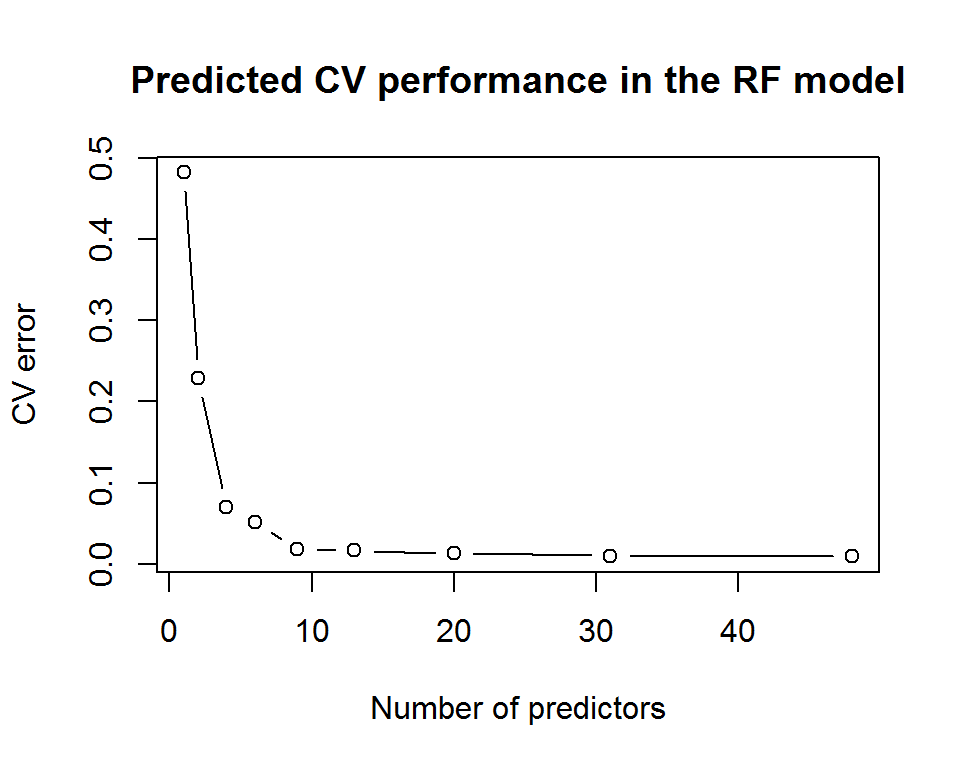

In the light of the previous graph, we can define a grid of `mtry` values from 5 to 25. The other relevant RF parameter, number of trees to grow (`ntree`), is fixed in 60 to make the model computable with limited resources. After executing the model, we will check if this number is acceptable:

Cross validation shows how the accuracy depends on the `mtry` parameter:

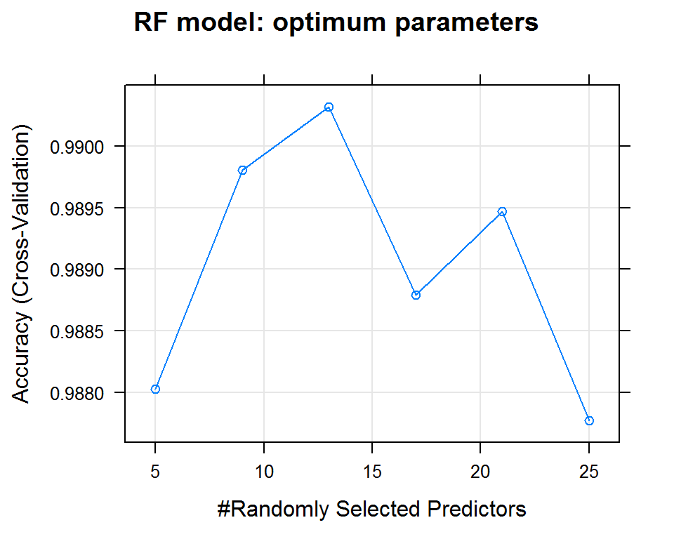

Once we have trained the model, we can check now if the number of trees fixed in the model is acceptable:

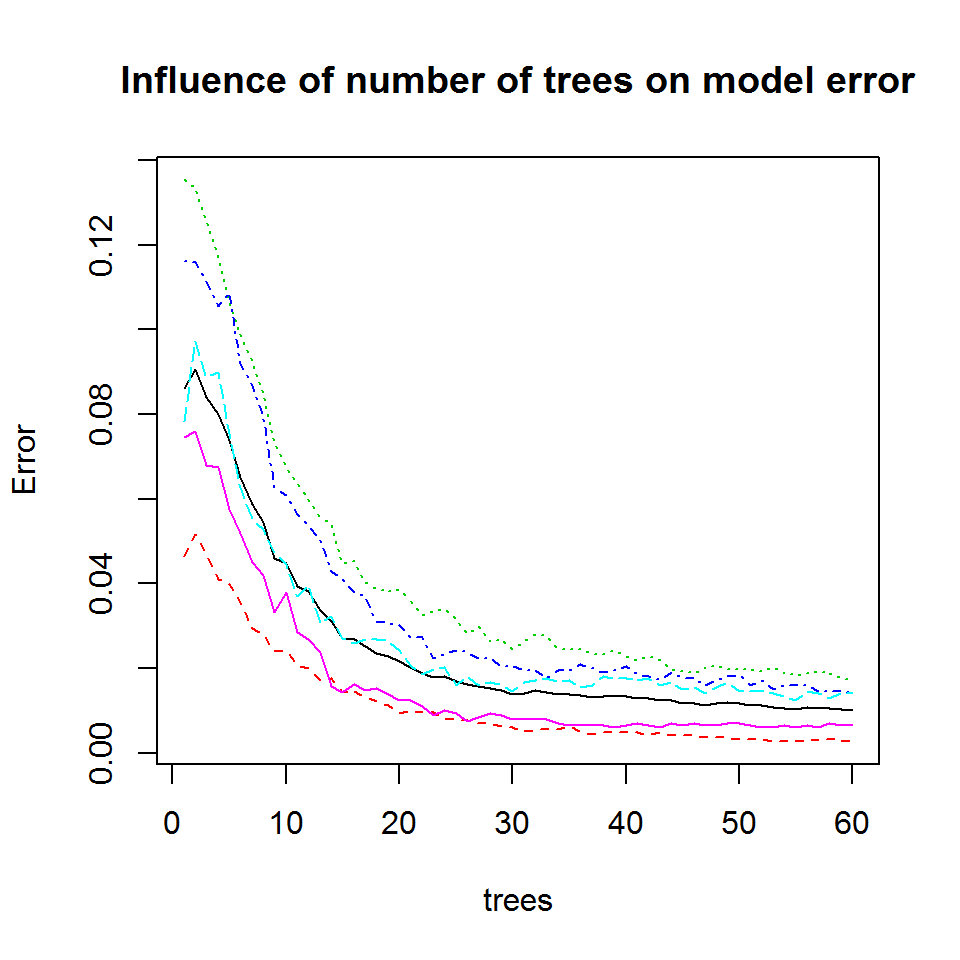

As can be seen, 60 trees is an acceptable value as the error rate is almost flat from around 40.

We can apply the final model, which have a `mtry` value of 13 and a `ntree` value of 60, to the `validating` subset for getting the accuracy and estimating the probability of predicting the 20 test cases correctly:

```
Confusion Matrix and Statistics

          Reference
Prediction    A    B    C    D    E
         A 2232   11    0    0    0
         B    0 1503    8    0    0
         C    0    4 1354   13    2
         D    0    0    6 1273    3
         E    0    0    0    0 1437

Overall Statistics

               Accuracy : 0.994
                 95% CI : (0.992, 0.9956)
    No Information Rate : 0.2845
    P-Value [Acc > NIR] : < 2.2e-16

                  Kappa : 0.9924
 Mcnemar's Test P-Value : NA

Statistics by Class:

                     Class: A Class: B Class: C Class: D Class: E
Sensitivity            1.0000   0.9901   0.9898   0.9899   0.9965
Specificity            0.9980   0.9987   0.9971   0.9986   1.0000
Pos Pred Value         0.9951   0.9947   0.9862   0.9930   1.0000
Neg Pred Value         1.0000   0.9976   0.9978   0.9980   0.9992
Prevalence             0.2845   0.1935   0.1744   0.1639   0.1838
Detection Rate         0.2845   0.1916   0.1726   0.1622   0.1832
Detection Prevalence   0.2859   0.1926   0.1750   0.1634   0.1832
Balanced Accuracy      0.9990   0.9944   0.9934   0.9943   0.9983
```

```
Probability of predicting test cases correctly: 0.8867727
```

The accuracy with the `validating` subset is excellent. This RF model shows a high probability to predict correctly the `testing` dataset with 20 test cases.

Go to the appendix The Random Forest model to see the R code used for this phase.

In you want to see more details on the training process and results go to the appendix Detailed process and final results of the RF model.

## 3.4 Generalized Boosted Model (GBM)

Generalized Boosted models are supported by the `gbm` package. In a GB model there are many fitting parameters. Find the right balance between them using a cross validation approach is a computationally demanding task, so we will use in our case part of the key parameters, keeping fixed the rest.

In detail, we define a grid of parameters, varying `interaction.depth` (maximum depth of predictors interaction) between 10 and 15 and `n.minobsinnode` (minimum number of observations in the terminal nodes) between 50 and 150, and keeping fixed `shrinkage` and `n.trees`.

Cross validation shows how the accuracy depends on those parameters:

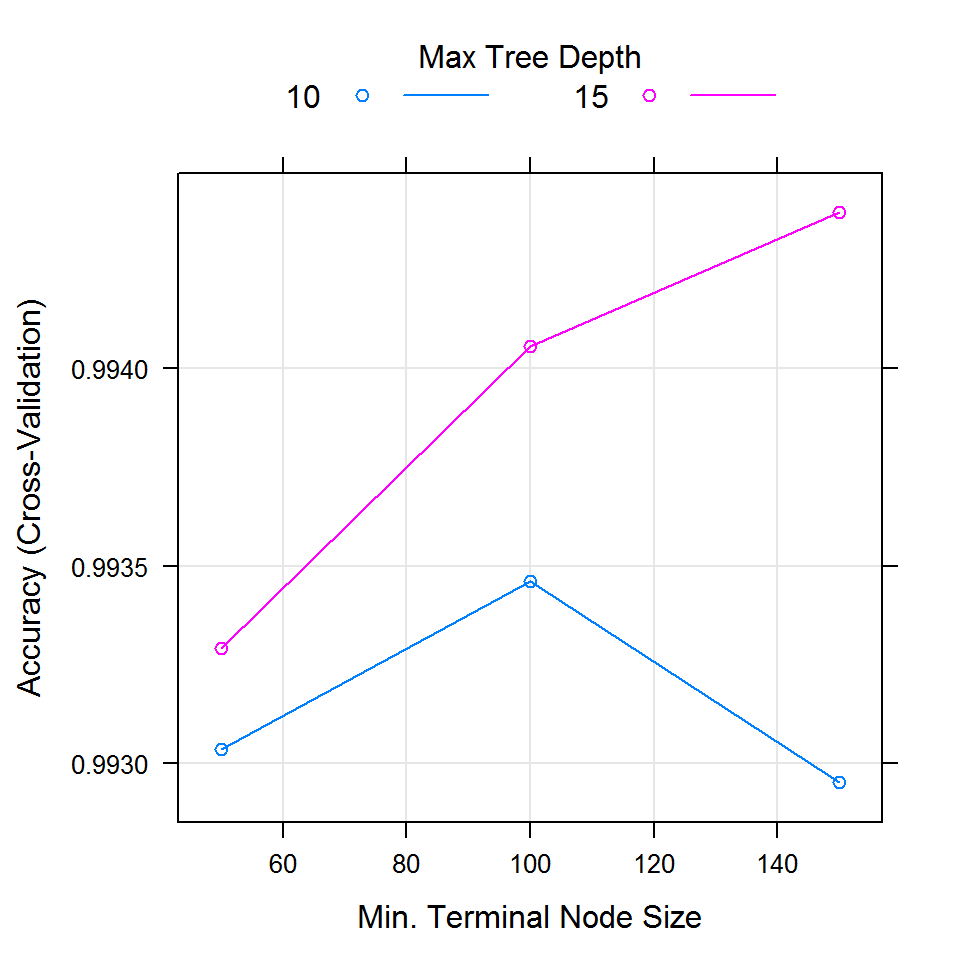

Now we can apply the final model, which has a `interaction.depth` value of 15 and a `n.minobsinnode` value of 150, to the `validating` subset for getting the accuracy and estimating the probability of predicting the 20 test cases correctly:

```
Confusion Matrix and Statistics

          Reference
Prediction    A    B    C    D    E
         A 2232    3    0    0    0
         B    0 1511    4    0    0
         C    0    2 1355    9    2
         D    0    0    9 1277    3
         E    0    2    0    0 1437

Overall Statistics

               Accuracy : 0.9957
                 95% CI : (0.9939, 0.997)
    No Information Rate : 0.2845
    P-Value [Acc > NIR] : < 2.2e-16

                  Kappa : 0.9945
 Mcnemar's Test P-Value : NA

Statistics by Class:

                     Class: A Class: B Class: C Class: D Class: E
Sensitivity            1.0000   0.9954   0.9905   0.9930   0.9965
Specificity            0.9995   0.9994   0.9980   0.9982   0.9997
Pos Pred Value         0.9987   0.9974   0.9905   0.9907   0.9986
Neg Pred Value         1.0000   0.9989   0.9980   0.9986   0.9992
Prevalence             0.2845   0.1935   0.1744   0.1639   0.1838
Detection Rate         0.2845   0.1926   0.1727   0.1628   0.1832
Detection Prevalence   0.2849   0.1931   0.1744   0.1643   0.1834
Balanced Accuracy      0.9997   0.9974   0.9942   0.9956   0.9981
```

```
Probability of predicting test cases correctly: 0.9168085
```

The accuracy with the `validating` subset is also excellent and slightly better than with the RF model. We will evaluate later if this difference is statistically significant. This GB model has a high probability to predict correctly the `testing` dataset with 20 test cases.

Go to the appendix The Generalizad Boosted Model to see the R code used for this phase.

In you want to see more details on the training process and results go to the appendix Detailed process and final results of the GB model.

# 4 Final model selection

In order to select the best classification method with solid statistical bases, we can use the capabilities the `caret` package offers to compare metrics from different models, provided that they use the same resampling techniques and data. Which is our case with cross validation based on 5 k-folds and setting the same seed before any `train()` invocation.

First of all, let see the distribution of accuracy metrics from the models we have consider in this study:

```
Call:
summary.resamples(object = resamp, metric = "Accuracy")

Models: CART, RF, GBM
Number of resamples: 5

Accuracy
       Min. 1st Qu. Median   Mean 3rd Qu.   Max. NA's
CART 0.6246  0.6500 0.6654 0.6572  0.6681 0.6778    0
RF   0.9860  0.9907 0.9907 0.9903  0.9915 0.9928    0
GBM  0.9915  0.9932 0.9945 0.9944  0.9945 0.9983    0
```

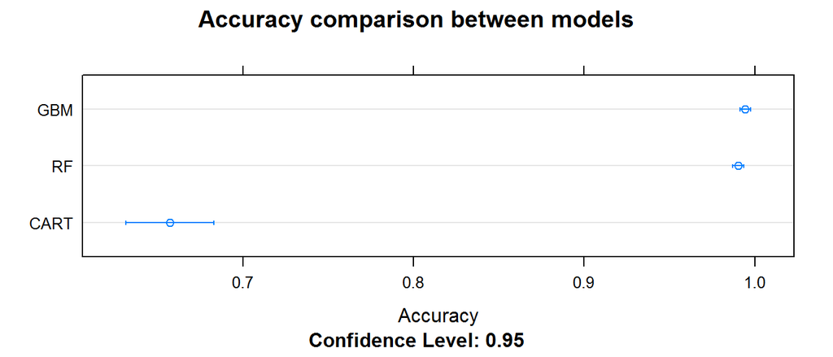

As we already known, the models RF and GBM are very close and far away of the CART model. Moreover, both have narrower IQ ranges.

Now we can check if the differences between RF and GBM accuracies are statistically significant using a `t-tests` with Bonferroni correction. The null hypothesis is $H_o: RF_{accu} = GBM_{accu}$ and the alternate one $H_a: RF_{accu} \neq GBM_{accu}$:

```
Call:
summary.diff.resamples(object = diff)

p-value adjustment: bonferroni
Upper diagonal: estimates of the difference
Lower diagonal: p-value for H0: difference = 0

Accuracy
     CART      RF        GBM
CART           -0.333138 -0.337214
RF   1.182e-05           -0.004076
GBM  7.449e-06 0.08483

Kappa
     CART      RF        GBM
CART           -0.422892 -0.428049
RF   1.069e-05           -0.005158
GBM  6.763e-06 0.08476
```

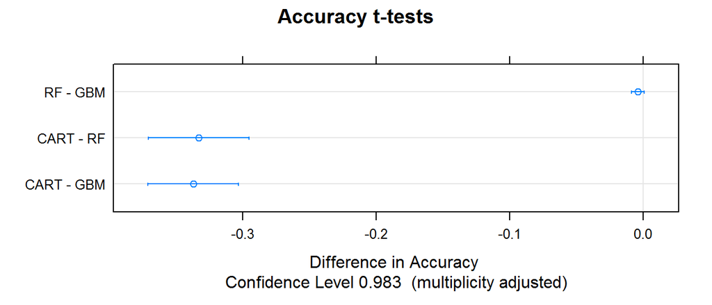

As can be seen, the C.I. for the difference between GBM and RF accuracies includes 0 and the p-value is 0.08483 > 0.05. At a confidence level of 95%, we fail to reject the null hypothesis and we must consider GBM and RF as equally accurate models.

Taking this into account, together the fact that computational demands are considerably higher in Generalized Boosted models, we finally choose Random Forest as the optimal classification model for our scenario.

Go to the appendix Selecting the final model to see the R code used in this phase.

# 5 Predicting the activity classes in the `testing` dataset

Once we have chosen the RF model, we can proceed to predict activity classes in the `testing` dataset.

After applying the RF model, the predicted outcomes for the 20 test cases are:

```
 1  2  3  4  5  6  7  8  9 10 11 12 13 14 15 16 17 18 19 20
 B  A  B  A  A  E  D  B  A  A  B  C  B  A  E  E  A  B  B  B
Levels: A B C D E
```

Go to the appendix Predicting the activity classes in the testing dataset to see the R code used in this phase.

# 6 Conclusions

The Random Forest and the Generalized Boosted classification models, properly parametrized and trained, are appropriate for predicting the quality outcome of the weight lifting exercise. Both models have reached an excellent accuracy and the probability of correctly predicting a testing dataset is sufficiently high.

As they are equally accurate in statistical terms, we recommend the use of the Random Forest model in case you have a limited CPU/Memory platform as its computational demands are much lower.

# 7 Appendices: I - R Code

## 7.1 Loading files and generating raw datasets

```r
########################################
# Loading necessary packages
#########################################

require(caret)
require(randomForest)
require(rpart)
require(gbm)
require(MASS)
require(plyr)
```

```r
###############################################################
# Downloading (if necessary) the original files from the source
################################################################

# Setting the data directory
file_dir <- file.path("C:/Data Science/02 Coursera/08 Machine Learning", "data")

# Loading the training file if not yet available
file_fullname <- file.path(file_dir, "pml-training.csv")
if (!file.exists(file_fullname)) {
    fileUrl <-
        "https://d396qusza40orc.cloudfront.net/predmachlearn/pml-training.csv"
    download.file(fileUrl, destfile = file_fullname, method = "libcurl")
}

# Loading the testing file if not yet available
file_fullname <- file.path(file_dir, "pml-testing.csv")
if (!file.exists(file_fullname)) {
    fileUrl <-
        "https://d396qusza40orc.cloudfront.net/predmachlearn/pml-testing.csv"
    download.file(fileUrl, destfile = file_fullname, method = "libcurl")
}
```

```r
########################################################
# Generating the raw datasets from the csv files
########################################################

# Generating the raw training dataset
wle.raw <- read.csv(file.path(file_dir, "pml-training.csv"),
                         row.names = 1, na.strings = c("", "NA", "#DIV/0!"),
                         stringsAsFactors = FALSE)

# Generating the raw testing dataset
wle.testing.raw <- read.csv(file.path(file_dir, "pml-testing.csv"),
                    row.names = 1, na.strings = c("", "NA", "#DIV/0!"),
                    stringsAsFactors = FALSE)
```

## 7.2 Exploratory analysis

```r
####################################
# Distribution of activity classes
####################################

print(table(wle.raw$classe))
```

```r
###################################################
# Calculating how many columns contains mainly NAs
###################################################

colNAs <- 0

# Covering all the variables (columns) in the dataset
for(col in colnames(wle.raw)){
    # Calculating the number of NAs in each column
    NAs <- sum(is.na(wle.raw[, col]))
    # Checking if it is bigger than 90% of thw number of dataset rows
    if (NAs > 0.9 * nrow(wle.raw)) {
        colNAs <- colNAs + 1
    }
}
cat("\n Number of variables with > 90% of NA values:", colNAs)
```

## 7.3 Cleaning the datasets

```r
#############################################
# Deleting columns not feasible as predictors
#############################################

# Determining  Near Zero Variations columns
nzvPred <- nearZeroVar(wle.raw)

# Determining columns with more than 90% of NAs
colNA <- sapply(1:ncol(wle.raw),
                function(i){sum(is.na(wle.raw[, i])) > 0.90 * nrow(wle.raw)})
NAPred <- which(colNA == TRUE)

# Determining first 6 colums with auxiliary experimental info but not measures
NoPred <- seq(1:6)

# Summing up all the irrelevant columns and suppresing them to generate a clean dataset
delPred <- unique(c(NAPred, nzvPred, NoPred))
wle <- wle.raw[, -delPred]

# Looking for high correlated predictors and deleting them
# (withouth taking into account 'classe' outcome)
outcome <- which(colnames(wle) == "classe")
predictCor <- cor(wle[, -outcome])
highCorPredictCor <- findCorrelation(predictCor, cutoff = 0.95)
wle <- wle[, -highCorPredictCor]

# Converting outcome in a categorical variable
wle$classe <- as.factor(wle$classe)

# Finding the final columns in the clean wle dataset and selecting them
# for generating the same estructure in the testing data set
finalCols <- which(colnames(wle.testing.raw) %in% colnames(wle))
wle.testing <- wle.testing.raw[, finalCols]
```

## 7.4 Preliminary steps: cross validation configuration and dataset splitting

```r
#####################################################
# Cross validation configuration for train() function
#####################################################

# Enabling parallel computing in multicore processors
library(foreach)
library(iterators)
library(parallel)
library(doParallel)
cluster <- makeCluster(detectCores() - 1) # convention to leave 1 core for OS
registerDoParallel(cluster)

# Fixing trControl parameters for train()
# CV with k-folds = 5 and allow parallel when applicable.
cvParam <- trainControl(method="cv", number=5, verboseIter = FALSE,
                        allowParallel = TRUE)
```

```r
###############################################
# Splitting the training dataset in two subsets
###############################################

set.seed(150658)

# Create a 60/40 split in the original training dataset
train <- createDataPartition(wle$classe, p = 0.60, list = FALSE)
training <- wle[train, ]
validating <- wle[-train, ]
```

## 7.5 The CART model

```r
#####################################
# Training the CART model
#####################################

set.seed(150658)

# Grid of cp values to be used in the train cross-validated process
rpartGrid <- expand.grid(cp = seq(0.0000, 0.005, by = 0.0005))

# Training the model with the grid of cp values and a minbucket size of 200
model_rpart <- train(classe ~ ., data = training,
                     method = "rpart", control = rpart.control(minbucket = 200),
                     tuneGrid = rpartGrid, trControl = cvParam)
```

```r
####################################
# Showing Accuracy vs. cp parameter
####################################

plot(model_rpart, main = "CART model: optimum parameters")
```

```r
#####################################################################
# Predicting the results in the validating subset with the CART model
#####################################################################

# Predicting the result of the model over the validating subset
pred <- predict(model_rpart, validating, type = "raw")

# Printing the results in a confusion matrix
cm <- confusionMatrix(pred,validating$classe)
print(cm)

# Probability of predicting the test cases
cat("\nProbability of predicting test cases correctly:",
    (cm$overall["Accuracy"]) ^ 20, "\n")
```

## 7.6 The Random Forest model

```r
##############################################################
# Prediction of CV error as a function of number of predictors
##############################################################

set.seed(150658)

# Converting dataset in the matrix format required by function rfcv
predWle <- model.matrix(classe ~ .-1, data = training)

# Predicting CV error in terms of number of predictors
cvpred <- rfcv(predWle, training$classe, cv.fold = 5, step = 0.65)

plot(cvpred$error.cv ~ as.numeric(names(cvpred$error.cv)), type = "b",
     main = "Predicted CV performance in the RF model",
     xlab = "Number of predictors", ylab = "CV error")
```

```r
#####################################
# Training the RF model
#####################################

set.seed(150658)

# Defining the grid of mtry values
rfGrid <- expand.grid(mtry = seq(5, 25, by = 4))

# Training the model with the grid of mtry values and a ntree size of 60
model_rf <- train(classe ~ ., data = training,
               method = "rf", ntree= 60, trControl = cvParam,
               tuneGrid = rfGrid)
```

```r
####################################
# Showing Accuracy vs. mtry parameter
####################################

plot(model_rf, main = "RF model: optimum parameters")
```

```r
####################################
# Showing Error vs. ntree parameter
####################################

plot(model_rf$finalModel, main = "Influence of number of trees on model error")
```

```r
#####################################################################
# Predicting the results in the validating subset with the RF model
#####################################################################

# Predicting the result of the model over the validating subset
pred <- predict(model_rf, validating, type = "raw")

# Printing the results in a confusion matrix
cm <- confusionMatrix(pred,validating$classe)
print(cm)

# Probability of predicting the test cases
cat("\nProbability of predicting test cases correctly:",
    (cm$overall["Accuracy"]) ^ 20, "\n")
```

## 7.7 The Generalized Boosted Model

```r
#####################################
# Training the GBM model
#####################################

set.seed(150658)

# Defining the grid of parameter values
gbmGrid <-  expand.grid(interaction.depth = c(10, 15),
                        n.trees = 300,
                        shrinkage = 0.1,
                        n.minobsinnode = c(50, 100, 150))

# Training the GB model with the grid of values
model_gbm <- train(classe ~ ., data = training,
                   method = "gbm", trControl = cvParam, verbose = FALSE,
                   tuneGrid = gbmGrid)
```

```r
########################################
# Showing Accuracy vs. model parameters
#######################################

plot(model_gbm, plotType = "scatter")
```

```r
#####################################################################
# Predicting the results in the validating subset with the GB model
#####################################################################

# Predicting the result of the model over the validating subset
pred <- predict(model_gbm, validating, type = "raw")

# Printing the results in a confusion matrix
cm <- confusionMatrix(pred,validating$classe)
print(cm)

# Probability of predicting the test cases
cat("\nProbability of predicting test cases correctly:",
    (cm$overall["Accuracy"]) ^ 20, "\n")
```

## 7.8 Selecting the final model

```r
##########################################
# Comparing accuracy metric between models
##########################################

# Resampling and comparing the models
resamp <- resamples(list(CART = model_rpart, RF = model_rf, GBM = model_gbm))

# Showing the comparison
summary(resamp, metric = "Accuracy")
dotplot(resamp, metric = "Accuracy", main = "Accuracy comparison between models")
```

```r
##################################################
# Doing t-test (Bonferroni adjusted) with accuracies
##################################################

# t-tests with Bonferroni correction for accuracy models
diff <- diff(resamp)

# Showing results
summary(diff)
dotplot(diff, metric = "Accuracy", main = "Accuracy t-tests")

# As it is the last code chunk in the report, we close the defined clusters
stopCluster(cluster)
```

## 7.9 Predicting the activity classes in the testing dataset

```r
##################################################
# Generating the prediction for the testing dataset
##################################################

# Predicting the outcome
outcome <- predict(model_rf, wle.testing, type = "raw")

# Asigning the test case indentifier to every outcome
names(outcome) <-  wle.testing.raw$problem_id

# Printing the resuts
print(outcome)
```

# 8 Appendices: II - Model’s details.

## 8.1 Detailed process and final tree of the CART model

```r
print(model_rpart)
```

```
CART

11776 samples
   48 predictor
    5 classes: 'A', 'B', 'C', 'D', 'E'

No pre-processing
Resampling: Cross-Validated (5 fold)
Summary of sample sizes: 9421, 9420, 9422, 9421, 9420
Resampling results across tuning parameters:

  cp      Accuracy   Kappa
  0.0000  0.6561625  0.5643002
  0.0005  0.6568419  0.5650942
  0.0010  0.6566713  0.5642777
  0.0015  0.6566713  0.5642777
  0.0020  0.6571808  0.5648601
  0.0025  0.6570110  0.5644634
  0.0030  0.6570110  0.5644634
  0.0035  0.6567563  0.5641762
  0.0040  0.6567563  0.5641762
  0.0045  0.6567563  0.5641762
  0.0050  0.6567563  0.5641762

Accuracy was used to select the optimal model using  the largest value.
The final value used for the model was cp = 0.002.
```

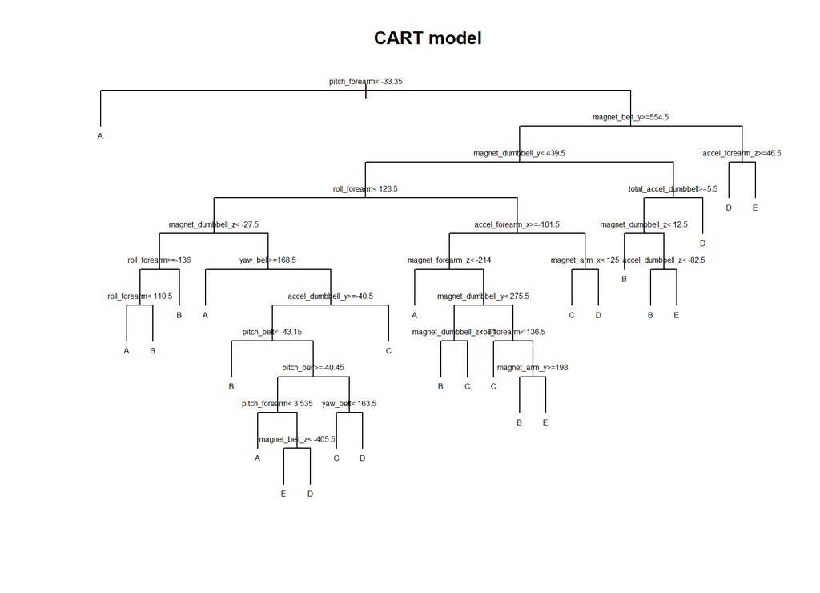

```r
plot(model_rpart$finalModel, uniform = TRUE,
     main = "CART model")
text(model_rpart$finalModel, pretty = 0, cex = 0.5)
```

## 8.2 Detailed process and final results of the RF model

```r
print(model_rf)
```

```
Random Forest

11776 samples
   48 predictor
    5 classes: 'A', 'B', 'C', 'D', 'E'

No pre-processing
Resampling: Cross-Validated (5 fold)
Summary of sample sizes: 9421, 9420, 9422, 9421, 9420
Resampling results across tuning parameters:

  mtry  Accuracy   Kappa
   5    0.9880258  0.9848499
   9    0.9898091  0.9871062
  13    0.9903188  0.9877516
  17    0.9887902  0.9858177
  21    0.9894699  0.9866772
  25    0.9877715  0.9845280

Accuracy was used to select the optimal model using  the largest value.
The final value used for the model was mtry = 13.
```

```r
print(model_rf$finalModel)
```

```
Call:
 randomForest(x = x, y = y, ntree = 60, mtry = param$mtry)
               Type of random forest: classification
                     Number of trees: 60
No. of variables tried at each split: 13

        OOB estimate of  error rate: 1%
Confusion matrix:
     A    B    C    D    E class.error
A 3339    6    3    0    0 0.002688172
B   25 2240   12    0    2 0.017112769
C    1   19 2025    8    1 0.014118793
D    0    1   24 1903    2 0.013989637
E    0    2    5    7 2151 0.006466513
```

## 8.3 Detailed process and final results of the GB model

```r
print(model_gbm)
```

```
Stochastic Gradient Boosting

11776 samples
   48 predictor
    5 classes: 'A', 'B', 'C', 'D', 'E'

No pre-processing
Resampling: Cross-Validated (5 fold)
Summary of sample sizes: 9421, 9420, 9422, 9421, 9420
Resampling results across tuning parameters:

  interaction.depth  n.minobsinnode  Accuracy   Kappa
  10                  50             0.9930361  0.9911907
  10                 100             0.9934606  0.9917281
  10                 150             0.9929512  0.9910836
  15                  50             0.9932908  0.9915129
  15                 100             0.9940553  0.9924801
  15                 150             0.9943948  0.9929094

Tuning parameter 'n.trees' was held constant at a value of 300

Tuning parameter 'shrinkage' was held constant at a value of 0.1
Accuracy was used to select the optimal model using  the largest value.
The final values used for the model were n.trees = 300,
 interaction.depth = 15, shrinkage = 0.1 and n.minobsinnode = 150.
```

```r
print(model_gbm$finalModel)
```

```
A gradient boosted model with multinomial loss function.
300 iterations were performed.
There were 48 predictors of which 48 had non-zero influence.
```